# Data 621 - HW4

Devin Teran, Atina Karim, Tom Hill, Amit Kapoor

5/2/2021

## Overview

In this homework assignment, you will explore, analyze and model a data set containing approximately 8000 records representing a customer at an auto insurance company. Each record has two response variables. The first response variable, TARGET_FLAG, is a 1 or a 0. A “1” means that the person was in a car crash. A zero means that the person was not in a car crash. The second response variable is TARGET_AMT. This value is zero if the person did not crash their car. But if they did crash their car, this number will be a value greater than zero.

Your objective is to build multiple linear regression and binary logistic regression models on the training data to predict the probability that a person will crash their car and also the amount of money it will cost if the person does crash their car. You can only use the variables given to you (or variables that you derive from the variables provided). Below is a short description of the variables of interest in the data set:

#### Response Variables:

| VARIABLE NAME | DEFINITION | THEORETICAL EFFECT |
| --- | --- | --- |
| TARGET_FLAG | Was Car in a crash? 1=YES 0=NO | None |
| TARGET_AMT | If car was in a crash, what was the cost | None |

#### Explanatory Variables:

| VARIABLE NAME | DEFINITION | THEORETICAL EFFECT |
| --- | --- | --- |
| AGE | Age of Driver | Very young people tend to be risky. Maybe very old people also. |
| BLUEBOOK | Value of Vehicle | Unknown effect on probability of collision, but probably effect the payout if there is a crash |
| CAR_AGE | Vehicle Age | Unknown effect on probability of collision, but probably effect the payout if there is a crash |
| CAR_TYPE | Type of Car | Unknown effect on probability of collision, but probably effect the payout if there is a crash |
| CAR_USE | Vehicle Use | Commercial vehicles are driven more, so might increase probability of collision |
| CLM_FREQ | # Claims (Past 5 Years) | The more claims you filed in the past, the more you are likely to file in the future |
| EDUCATION | Max Education Level | Unknown effect, but in theory more educated people tend to drive more safely |
| HOMEKIDS | # Children at Home | Unknown effect |
| HOME_VAL | Home Value | In theory, home owners tend to drive more responsibly |
| INCOME | Income | In theory, rich people tend to get into fewer crashes |
| JOB | Job Category | In theory, white collar jobs tend to be safer |
| KIDSDRIV | # Driving Children | When teenagers drive your car, you are more likely to get into crashes |
| MSTATUS | Marital Status | In theory, married people drive more safely |
| MVR_PTS | Motor Vehicle Record Points | If you get lots of traffic tickets, you tend to get into more crashes |
| OLDCLAIM | Total Claims (Past 5 Years) | If your total payout over the past five years was high, this suggests future payouts will be high |
| PARENT1 | Single Parent | Unknown effect |
| RED_CAR | A Red Car | Urban legend says that red cars (especially red sports cars) are more risky. Is that true? |
| REVOKED | License Revoked (Past 7 Years) | If your license was revoked in the past 7 years, you probably are a more risky driver. |
| SEX | Gender | Urban legend says that women have less crashes then men. Is that true? |
| TIF | Time in Force | People who have been customers for a long time are usually more safe. |
| TRAVTIME | Distance to Work | Long drives to work usually suggest greater risk |
| URBANICITY | Home/Work Area | Unknown |
| YOJ | Years on Job | People who stay at a job for a long time are usually more safe |

## Data Exploration

```
## Rows: 8,161
## Columns: 26
## $ INDEX       <int> 1, 2, 4, 5, 6, 7, 8, 11, 12, 13, 14, 15, 16, 17, 19, 20, 2…
## $ TARGET_FLAG <int> 0, 0, 0, 0, 0, 1, 0, 1, 1, 0, 1, 0, 0, 1, 1, 0, 0, 0, 0, 1…
## $ TARGET_AMT  <dbl> 0.000, 0.000, 0.000, 0.000, 0.000, 2946.000, 0.000, 4021.0…
## $ KIDSDRIV    <int> 0, 0, 0, 0, 0, 0, 0, 1, 0, 0, 0, 0, 0, 0, 0, 0, 0, 0, 0, 0…
## $ AGE         <int> 60, 43, 35, 51, 50, 34, 54, 37, 34, 50, 53, 43, 55, 53, 45…
## $ HOMEKIDS    <int> 0, 0, 1, 0, 0, 1, 0, 2, 0, 0, 0, 0, 0, 0, 0, 3, 0, 3, 2, 1…
## $ YOJ         <int> 11, 11, 10, 14, NA, 12, NA, NA, 10, 7, 14, 5, 11, 11, 0, 1…
## $ INCOME      <chr> "$67,349", "$91,449", "$16,039", "", "$114,986", "$125,301…
## $ PARENT1     <chr> "No", "No", "No", "No", "No", "Yes", "No", "No", "No", "No…
## $ HOME_VAL    <chr> "$0", "$257,252", "$124,191", "$306,251", "$243,925", "$0"…
## $ MSTATUS     <chr> "z_No", "z_No", "Yes", "Yes", "Yes", "z_No", "Yes", "Yes",…
## $ SEX         <chr> "M", "M", "z_F", "M", "z_F", "z_F", "z_F", "M", "z_F", "M"…
## $ EDUCATION   <chr> "PhD", "z_High School", "z_High School", "<High School", "…
## $ JOB         <chr> "Professional", "z_Blue Collar", "Clerical", "z_Blue Colla…
## $ TRAVTIME    <int> 14, 22, 5, 32, 36, 46, 33, 44, 34, 48, 15, 36, 25, 64, 48,…
## $ CAR_USE     <chr> "Private", "Commercial", "Private", "Private", "Private", …
## $ BLUEBOOK    <chr> "$14,230", "$14,940", "$4,010", "$15,440", "$18,000", "$17…
## $ TIF         <int> 11, 1, 4, 7, 1, 1, 1, 1, 1, 7, 1, 7, 7, 6, 1, 6, 6, 7, 4, …
## $ CAR_TYPE    <chr> "Minivan", "Minivan", "z_SUV", "Minivan", "z_SUV", "Sports…
## $ RED_CAR     <chr> "yes", "yes", "no", "yes", "no", "no", "no", "yes", "no", …
## $ OLDCLAIM    <chr> "$4,461", "$0", "$38,690", "$0", "$19,217", "$0", "$0", "$…
## $ CLM_FREQ    <int> 2, 0, 2, 0, 2, 0, 0, 1, 0, 0, 0, 0, 2, 0, 0, 0, 0, 0, 0, 2…
## $ REVOKED     <chr> "No", "No", "No", "No", "Yes", "No", "No", "Yes", "No", "N…
## $ MVR_PTS     <int> 3, 0, 3, 0, 3, 0, 0, 10, 0, 1, 0, 0, 3, 3, 3, 0, 0, 0, 0, …
## $ CAR_AGE     <int> 18, 1, 10, 6, 17, 7, 1, 7, 1, 17, 11, 1, 9, 10, 5, 13, 16,…
## $ URBANICITY  <chr> "Highly Urban/ Urban", "Highly Urban/ Urban", "Highly Urba…
```

```
##   INDEX TARGET_FLAG TARGET_AMT KIDSDRIV AGE HOMEKIDS YOJ   INCOME PARENT1
## 1     1           0          0        0  60        0  11  $67,349      No
## 2     2           0          0        0  43        0  11  $91,449      No
## 3     4           0          0        0  35        1  10  $16,039      No
## 4     5           0          0        0  51        0  14               No
## 5     6           0          0        0  50        0  NA $114,986      No
## 6     7           1       2946        0  34        1  12 $125,301     Yes
##   HOME_VAL MSTATUS SEX     EDUCATION           JOB TRAVTIME    CAR_USE BLUEBOOK
## 1       $0    z_No   M           PhD  Professional       14    Private  $14,230
## 2 $257,252    z_No   M z_High School z_Blue Collar       22 Commercial  $14,940
## 3 $124,191     Yes z_F z_High School      Clerical        5    Private   $4,010
## 4 $306,251     Yes   M  <High School z_Blue Collar       32    Private  $15,440
## 5 $243,925     Yes z_F           PhD        Doctor       36    Private  $18,000
## 6       $0    z_No z_F     Bachelors z_Blue Collar       46 Commercial  $17,430
##   TIF   CAR_TYPE RED_CAR OLDCLAIM CLM_FREQ REVOKED MVR_PTS CAR_AGE
## 1  11    Minivan     yes   $4,461        2      No       3      18
## 2   1    Minivan     yes       $0        0      No       0       1
## 3   4      z_SUV      no  $38,690        2      No       3      10
## 4   7    Minivan     yes       $0        0      No       0       6
## 5   1      z_SUV      no  $19,217        2     Yes       3      17
## 6   1 Sports Car      no       $0        0      No       0       7
##            URBANICITY
## 1 Highly Urban/ Urban
## 2 Highly Urban/ Urban
## 3 Highly Urban/ Urban
## 4 Highly Urban/ Urban
## 5 Highly Urban/ Urban
## 6 Highly Urban/ Urban
```

```
##      INDEX        TARGET_FLAG       TARGET_AMT        KIDSDRIV
##  Min.   :    1   Min.   :0.0000   Min.   :     0   Min.   :0.0000
##  1st Qu.: 2559   1st Qu.:0.0000   1st Qu.:     0   1st Qu.:0.0000
##  Median : 5133   Median :0.0000   Median :     0   Median :0.0000
##  Mean   : 5152   Mean   :0.2638   Mean   :  1504   Mean   :0.1711
##  3rd Qu.: 7745   3rd Qu.:1.0000   3rd Qu.:  1036   3rd Qu.:0.0000
##  Max.   :10302   Max.   :1.0000   Max.   :107586   Max.   :4.0000
##
##       AGE           HOMEKIDS           YOJ          INCOME
##  Min.   :16.00   Min.   :0.0000   Min.   : 0.0   Length:8161
##  1st Qu.:39.00   1st Qu.:0.0000   1st Qu.: 9.0   Class :character
##  Median :45.00   Median :0.0000   Median :11.0   Mode  :character
##  Mean   :44.79   Mean   :0.7212   Mean   :10.5
##  3rd Qu.:51.00   3rd Qu.:1.0000   3rd Qu.:13.0
##  Max.   :81.00   Max.   :5.0000   Max.   :23.0
##  NA's   :6                        NA's   :454
##    PARENT1            HOME_VAL           MSTATUS              SEX
##  Length:8161        Length:8161        Length:8161        Length:8161
##  Class :character   Class :character   Class :character   Class :character
##  Mode  :character   Mode  :character   Mode  :character   Mode  :character
##
##
##
##
##   EDUCATION             JOB               TRAVTIME        CAR_USE
##  Length:8161        Length:8161        Min.   :  5.00   Length:8161
##  Class :character   Class :character   1st Qu.: 22.00   Class :character
##  Mode  :character   Mode  :character   Median : 33.00   Mode  :character
##                                        Mean   : 33.49
##                                        3rd Qu.: 44.00
##                                        Max.   :142.00
##
##    BLUEBOOK              TIF           CAR_TYPE           RED_CAR
##  Length:8161        Min.   : 1.000   Length:8161        Length:8161
##  Class :character   1st Qu.: 1.000   Class :character   Class :character
##  Mode  :character   Median : 4.000   Mode  :character   Mode  :character
##                     Mean   : 5.351
##                     3rd Qu.: 7.000
##                     Max.   :25.000
##
##    OLDCLAIM            CLM_FREQ        REVOKED             MVR_PTS
##  Length:8161        Min.   :0.0000   Length:8161        Min.   : 0.000
##  Class :character   1st Qu.:0.0000   Class :character   1st Qu.: 0.000
##  Mode  :character   Median :0.0000   Mode  :character   Median : 1.000
##                     Mean   :0.7986                      Mean   : 1.696
##                     3rd Qu.:2.0000                      3rd Qu.: 3.000
##                     Max.   :5.0000                      Max.   :13.000
##
##     CAR_AGE        URBANICITY
##  Min.   :-3.000   Length:8161
##  1st Qu.: 1.000   Class :character
##  Median : 8.000   Mode  :character
##  Mean   : 8.328
##  3rd Qu.:12.000
##  Max.   :28.000
##  NA's   :510
```

There are several recurring issues with some columns: all columns containing money amounts have incomptaible punctuation and characters. Also, categorical variables neeed to be changed to factors and their factor names edited for intelligibility.

```
##   TARGET_FLAG       TARGET_AMT        KIDSDRIV           AGE
##  Min.   :0.0000   Min.   :     0   Min.   :0.0000   Min.   :16.00
##  1st Qu.:0.0000   1st Qu.:     0   1st Qu.:0.0000   1st Qu.:39.00
##  Median :0.0000   Median :     0   Median :0.0000   Median :45.00
##  Mean   :0.2638   Mean   :  1504   Mean   :0.1711   Mean   :44.79
##  3rd Qu.:1.0000   3rd Qu.:  1036   3rd Qu.:0.0000   3rd Qu.:51.00
##  Max.   :1.0000   Max.   :107586   Max.   :4.0000   Max.   :81.00
##                                                     NA's   :6
##     HOMEKIDS           YOJ           INCOME       PARENT1       HOME_VAL
##  Min.   :0.0000   Min.   : 0.0   Min.   :     0   No :7084   Min.   :     0
##  1st Qu.:0.0000   1st Qu.: 9.0   1st Qu.: 28097   Yes:1077   1st Qu.:     0
##  Median :0.0000   Median :11.0   Median : 54028              Median :161160
##  Mean   :0.7212   Mean   :10.5   Mean   : 61898              Mean   :154867
##  3rd Qu.:1.0000   3rd Qu.:13.0   3rd Qu.: 85986              3rd Qu.:238724
##  Max.   :5.0000   Max.   :23.0   Max.   :367030              Max.   :885282
##                   NA's   :454    NA's   :445                 NA's   :464
##  MSTATUS    SEX                      EDUCATION              JOB
##  No :3267   F:4375   Bachelors            :2242   Blue Collar :1825
##  Yes:4894   M:3786   High School          :2330   Clerical    :1271
##                      Less than High School:1203   Professional:1117
##                      Masters              :1658   Manager     : 988
##                      PhD                  : 728   Lawyer      : 835
##                                                   Student     : 712
##                                                   (Other)     :1413
##     TRAVTIME            CAR_USE        BLUEBOOK          TIF
##  Min.   :  5.00   Commercial:3029   Min.   : 1500   Min.   : 1.000
##  1st Qu.: 22.00   Private   :5132   1st Qu.: 9280   1st Qu.: 1.000
##  Median : 33.00                     Median :14440   Median : 4.000
##  Mean   : 33.49                     Mean   :15710   Mean   : 5.351
##  3rd Qu.: 44.00                     3rd Qu.:20850   3rd Qu.: 7.000
##  Max.   :142.00                     Max.   :69740   Max.   :25.000
##
##         CAR_TYPE    RED_CAR       OLDCLAIM        CLM_FREQ      REVOKED
##  Minivan    :2145   no :5783   Min.   :    0   Min.   :0.0000   No :7161
##  Panel Truck: 676   yes:2378   1st Qu.:    0   1st Qu.:0.0000   Yes:1000
##  Pickup     :1389              Median :    0   Median :0.0000
##  Sports Car : 907              Mean   : 4037   Mean   :0.7986
##  SUV        :2294              3rd Qu.: 4636   3rd Qu.:2.0000
##  Van        : 750              Max.   :57037   Max.   :5.0000
##
##     MVR_PTS          CAR_AGE                     URBANICITY
##  Min.   : 0.000   Min.   :-3.000   Highly Rural/ Rural:1669
##  1st Qu.: 0.000   1st Qu.: 1.000   Highly Urban/ Urban:6492
##  Median : 1.000   Median : 8.000
##  Mean   : 1.696   Mean   : 8.328
##  3rd Qu.: 3.000   3rd Qu.:12.000
##  Max.   :13.000   Max.   :28.000
##                   NA's   :510
```

The fixed dataframe now only includes columns that are numeric or factors. Car age appears to have some values less than 1, including a negative values. These will be changed to the mode of 1.

### Categorical variables

```
## [1] "PARENT1"
## [1] "No"  "Yes"
## [1] "MSTATUS"
## [1] "No"  "Yes"
## [1] "SEX"
## [1] "F" "M"
## [1] "EDUCATION"
## [1] "Bachelors"             "High School"           "Less than High School"
## [4] "Masters"               "PhD"
## [1] "JOB"
## [1] "Blue Collar"  "Clerical"     "Doctor"       "Home Maker"   "Lawyer"
## [6] "Manager"      "Other Job"    "Professional" "Student"
## [1] "CAR_USE"
## [1] "Commercial" "Private"
## [1] "CAR_TYPE"
## [1] "Minivan"     "Panel Truck" "Pickup"      "Sports Car"  "SUV"
## [6] "Van"
## [1] "RED_CAR"
## [1] "no"  "yes"
## [1] "REVOKED"
## [1] "No"  "Yes"
## [1] "URBANICITY"
## [1] "Highly Rural/ Rural" "Highly Urban/ Urban"
```

Looking at categorical variables, most of the columns are binary.

Below graphs shows the distribution of all categorical predictors.

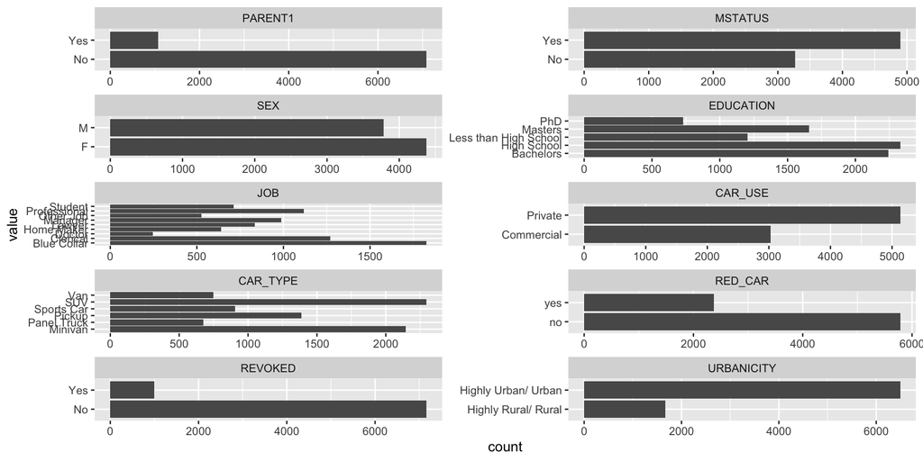

### Numeric Variables

Below 2 graphs shows the distribution of numeric variables. The red graphs are on normal scale and the green ones are on log10 scale. Many numeric variables feature the value of zero as a mode.

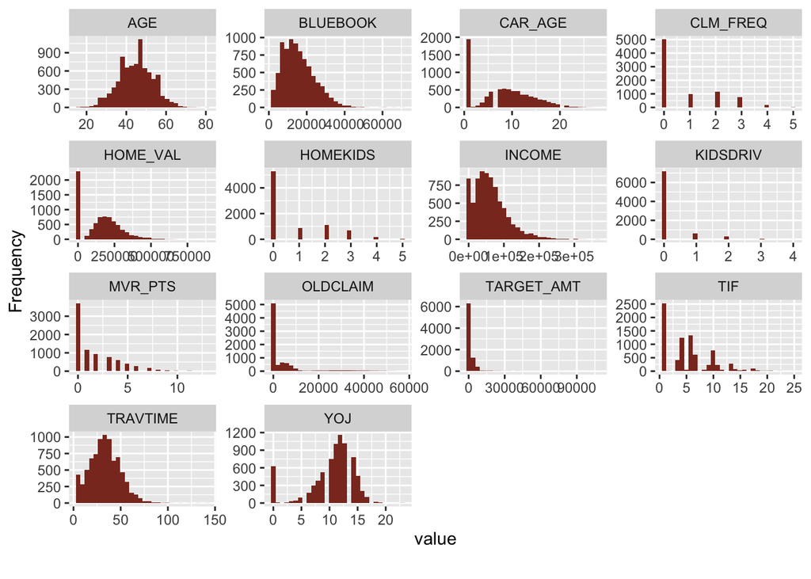

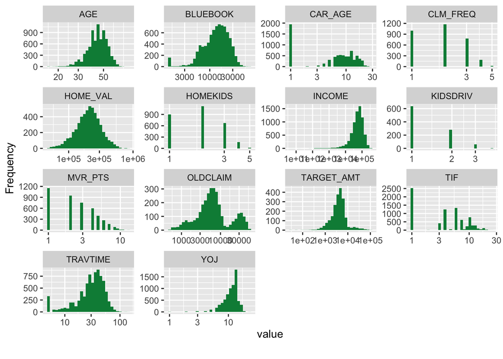

### Missing Values

Here are columns having missing values coded as NA:

```
##   AGE YOJ INCOME HOME_VAL CAR_AGE
## 1   6 454    445      464     510
```

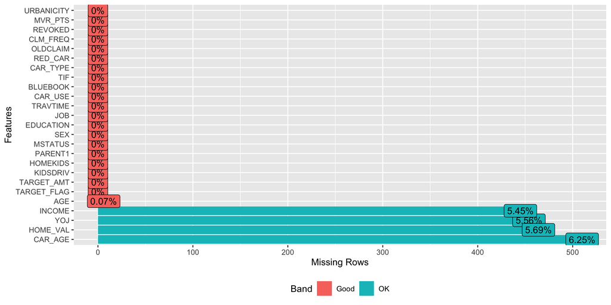

```
## TARGET_FLAG  TARGET_AMT    KIDSDRIV         AGE    HOMEKIDS         YOJ
##       0.000       0.000       0.000       0.001       0.000       0.056
##      INCOME     PARENT1    HOME_VAL     MSTATUS         SEX   EDUCATION
##       0.055       0.000       0.057       0.000       0.000       0.000
##         JOB    TRAVTIME     CAR_USE    BLUEBOOK         TIF    CAR_TYPE
##       0.000       0.000       0.000       0.000       0.000       0.000
##     RED_CAR    OLDCLAIM    CLM_FREQ     REVOKED     MVR_PTS     CAR_AGE
##       0.000       0.000       0.000       0.000       0.000       0.062
##  URBANICITY
##       0.000
```

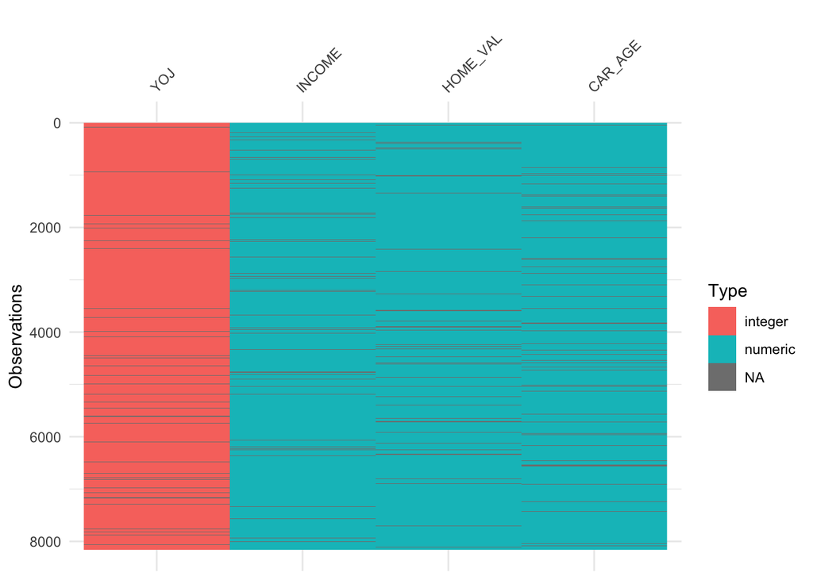

### Correlation

For the purposes of seeing correlation between variables, we’re going to replace NA values with the median.

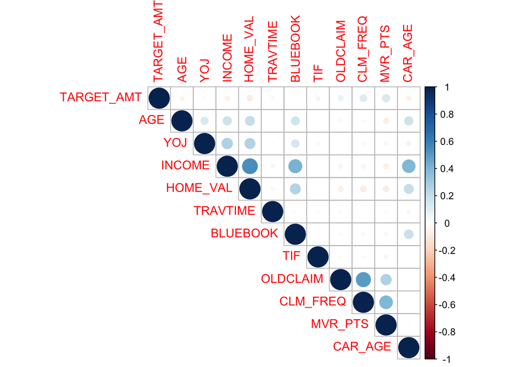

It’s clear there are some positive correlations between the following variables:  
* **Income** & **Home value**: 0.54  
* **Income** & **Bluebook**: 0.42  
* **Income** & **Car age**: 0.39  
* **Claim Frequency** & **Old claims**: 0.50  
* **Claim Frequence** & **MVR_PTS**:0.39

## Data Prepation

### Removing TARGET_FLAG

Our multiple linear regression model will be predicting the amount of money someone receives if they crash, so we will be removing the variable *TARGET_FLAG*

### Handling Missing Data - Multiple Linear Regression

For the multiple linear regression, we’re going to assume that the NULL values will take the median value for the variable.

### Transforming Variables - Multiple Linear Regression

There some variables that are not normally distributed so we’re going to try using a log transformation later to see if that creates a better model. For a few variables with values, 0, we added 1 to avoid negative infinity when taking the log of those variables. This will not alter our modeling results significantly.

### Zeroes in Home Value

It seems from the histogram above, that the mode of the variable HOME_VAL is 0. Given that, the distribution seems normal if we remove 0s and that the difference between 0 and the number that appears next on the axis is significant, we are assuming that 0 indicates missing values for HOME_VAL. Therefore, we will convert 0s to NAs in HOME_VAL prior to imputing missing values for Binary Logistic Regression Model 3 below.

## Build Models

### Model1

The first model to consider includes all given variables and does not impute any values.

```
##
## Call:
## glm(formula = TARGET_FLAG ~ . - TARGET_AMT, family = "binomial",
##     data = insurance_fix)
##
## Deviance Residuals:
##     Min       1Q   Median       3Q      Max
## -2.5843  -0.7124  -0.3998   0.6195   3.1633
##
## Coefficients:
##                                  Estimate Std. Error z value Pr(>|z|)
## (Intercept)                    -2.881e+00  3.199e-01  -9.005  < 2e-16 ***
## KIDSDRIV                        3.385e-01  6.908e-02   4.900 9.57e-07 ***
## AGE                            -3.665e-03  4.531e-03  -0.809 0.418503
## HOMEKIDS                        3.349e-02  4.176e-02   0.802 0.422588
## YOJ                            -1.071e-02  9.589e-03  -1.117 0.263837
## INCOME                         -2.988e-06  1.260e-06  -2.371 0.017738 *
## PARENT1Yes                      4.337e-01  1.225e-01   3.541 0.000398 ***
## HOME_VAL                       -1.301e-06  3.899e-07  -3.337 0.000848 ***
## MSTATUSYes                     -4.389e-01  9.666e-02  -4.541 5.61e-06 ***
## SEXM                            1.914e-01  1.241e-01   1.543 0.122880
## EDUCATIONHigh School            3.716e-01  1.020e-01   3.645 0.000268 ***
## EDUCATIONLess than High School  3.724e-01  1.306e-01   2.852 0.004342 **
## EDUCATIONMasters                2.887e-02  1.607e-01   0.180 0.857462
## EDUCATIONPhD                    2.617e-01  2.054e-01   1.274 0.202597
## JOBClerical                     2.052e-01  1.193e-01   1.720 0.085428 .
## JOBDoctor                      -5.011e-01  3.136e-01  -1.598 0.110084
## JOBHome Maker                  -8.529e-02  1.750e-01  -0.487 0.625972
## JOBLawyer                      -1.923e-02  2.126e-01  -0.090 0.927939
## JOBManager                     -8.826e-01  1.595e-01  -5.534 3.13e-08 ***
## JOBOther Job                   -3.071e-01  2.117e-01  -1.450 0.146938
## JOBProfessional                -1.066e-01  1.360e-01  -0.784 0.433062
## JOBStudent                     -1.370e-01  1.497e-01  -0.915 0.359966
## TRAVTIME                        1.562e-02  2.118e-03   7.374 1.66e-13 ***
## CAR_USEPrivate                 -8.256e-01  1.040e-01  -7.935 2.10e-15 ***
## BLUEBOOK                       -2.101e-05  5.885e-06  -3.570 0.000357 ***
## TIF                            -5.318e-02  8.241e-03  -6.453 1.10e-10 ***
## CAR_TYPEPanel Truck             6.097e-01  1.807e-01   3.374 0.000740 ***
## CAR_TYPEPickup                  5.246e-01  1.136e-01   4.619 3.85e-06 ***
## CAR_TYPESports Car              1.128e+00  1.450e-01   7.784 7.05e-15 ***
## CAR_TYPESUV                     8.518e-01  1.241e-01   6.866 6.59e-12 ***
## CAR_TYPEVan                     6.335e-01  1.421e-01   4.460 8.21e-06 ***
## RED_CARyes                     -1.227e-01  9.685e-02  -1.267 0.205139
## OLDCLAIM                       -1.180e-05  4.375e-06  -2.698 0.006977 **
## CLM_FREQ                        1.953e-01  3.183e-02   6.136 8.46e-10 ***
## REVOKEDYes                      8.644e-01  1.035e-01   8.354  < 2e-16 ***
## MVR_PTS                         1.143e-01  1.528e-02   7.485 7.16e-14 ***
## CAR_AGE                        -7.075e-03  8.448e-03  -0.837 0.402334
## URBANICITYHighly Urban/ Urban   2.313e+00  1.241e-01  18.640  < 2e-16 ***
## ---
## Signif. codes:  0 '***' 0.001 '**' 0.01 '*' 0.05 '.' 0.1 ' ' 1
##
## (Dispersion parameter for binomial family taken to be 1)
##
##     Null deviance: 7445.1  on 6447  degrees of freedom
## Residual deviance: 5764.7  on 6410  degrees of freedom
##   (1713 observations deleted due to missingness)
## AIC: 5840.7
##
## Number of Fisher Scoring iterations: 5
```

```
## Confusion Matrix and Statistics
##
##           Reference
## Prediction   0   1
##          0 862 188
##          1  77 149
##
##                Accuracy : 0.7923
##                  95% CI : (0.769, 0.8143)
##     No Information Rate : 0.7359
##     P-Value [Acc > NIR] : 1.650e-06
##
##                   Kappa : 0.4026
##
##  Mcnemar's Test P-Value : 1.406e-11
##
##             Sensitivity : 0.9180
##             Specificity : 0.4421
##          Pos Pred Value : 0.8210
##          Neg Pred Value : 0.6593
##              Prevalence : 0.7359
##          Detection Rate : 0.6755
##    Detection Prevalence : 0.8229
##       Balanced Accuracy : 0.6801
##
##        'Positive' Class : 0
##
```

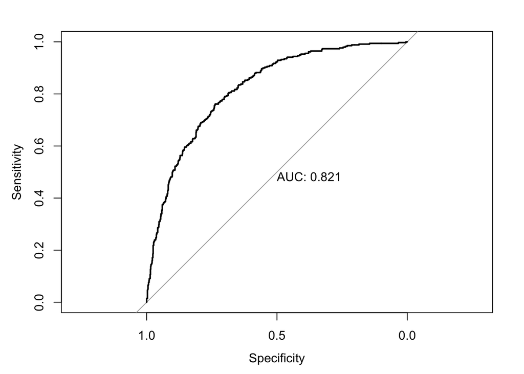

### Model2

The second model imputes values using the ‘mice’ library using classification and regression trees. We will use glm.mids() that applies glm() to a multiply imputed data set.

```
## call :
## glm.mids(formula = TARGET_FLAG ~ . - TARGET_AMT, family = "binomial",
##     data = insurance_impute)
##
## call1 :
## mice(data = insurance_fix, m = 1, method = "cart")
##
## nmis :
## TARGET_FLAG  TARGET_AMT    KIDSDRIV         AGE    HOMEKIDS         YOJ
##           0           0           0           6           0         454
##      INCOME     PARENT1    HOME_VAL     MSTATUS         SEX   EDUCATION
##         445           0         464           0           0           0
##         JOB    TRAVTIME     CAR_USE    BLUEBOOK         TIF    CAR_TYPE
##           0           0           0           0           0           0
##     RED_CAR    OLDCLAIM    CLM_FREQ     REVOKED     MVR_PTS     CAR_AGE
##           0           0           0           0           0         510
##  URBANICITY
##           0
##
## analyses :
## [[1]]
##
## Call:  glm(formula = formula, family = family, data = complete(data,
##     i))
##
## Coefficients:
##                    (Intercept)                        KIDSDRIV
##                     -2.896e+00                       3.840e-01
##                            AGE                        HOMEKIDS
##                     -6.800e-04                       5.566e-02
##                            YOJ                          INCOME
##                     -1.784e-02                      -3.413e-06
##                     PARENT1Yes                        HOME_VAL
##                      3.802e-01                      -1.293e-06
##                     MSTATUSYes                            SEXM
##                     -4.818e-01                       8.755e-02
##           EDUCATIONHigh School  EDUCATIONLess than High School
##                      3.765e-01                       3.506e-01
##               EDUCATIONMasters                    EDUCATIONPhD
##                      1.187e-01                       2.530e-01
```

[output cut: 13 more lines]

```
##                      5.559e-01                       5.547e-01
##             CAR_TYPESports Car                     CAR_TYPESUV
##                      1.023e+00                       7.681e-01
##                    CAR_TYPEVan                      RED_CARyes
##                      6.174e-01                      -1.227e-02
##                       OLDCLAIM                        CLM_FREQ
##                     -1.378e-05                       1.965e-01
##                     REVOKEDYes                         MVR_PTS
##                      8.870e-01                       1.133e-01
##                        CAR_AGE   URBANICITYHighly Urban/ Urban
##                     -5.686e-03                       2.391e+00
##
## Degrees of Freedom: 8160 Total (i.e. Null);  8123 Residual
## Null Deviance:       9418
## Residual Deviance: 7292  AIC: 7368
```

```
## Confusion Matrix and Statistics
##
##           Reference
## Prediction   0   1
##          0 878 190
##          1  70 136
##
##                Accuracy : 0.7959
##                  95% CI : (0.7727, 0.8177)
##     No Information Rate : 0.7441
##     P-Value [Acc > NIR] : 8.412e-06
##
##                   Kappa : 0.3905
##
##  Mcnemar's Test P-Value : 1.582e-13
##
##             Sensitivity : 0.9262
##             Specificity : 0.4172
##          Pos Pred Value : 0.8221
##          Neg Pred Value : 0.6602
##              Prevalence : 0.7441
##          Detection Rate : 0.6892
##    Detection Prevalence : 0.8383
##       Balanced Accuracy : 0.6717
##
##        'Positive' Class : 0
##
```

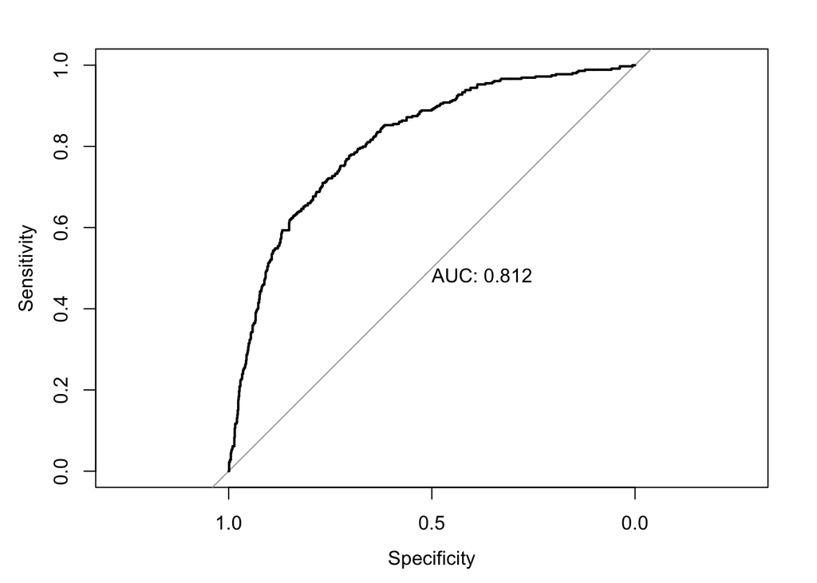

### Model 3

Now we will replicate the model above to see if our assumption about treating 0s in HOME_VAL as missing data, yields a better model fit.

```
## call :
## glm.mids(formula = TARGET_FLAG ~ . - TARGET_AMT, family = "binomial",
##     data = insurance_impute2)
##
## call1 :
## mice(data = insurance_fix2, m = 1, method = "cart")
##
## nmis :
## TARGET_FLAG  TARGET_AMT    KIDSDRIV         AGE    HOMEKIDS         YOJ
##           0           0           0           6           0         454
##      INCOME     PARENT1    HOME_VAL     MSTATUS         SEX   EDUCATION
##         445           0        2758           0           0           0
##         JOB    TRAVTIME     CAR_USE    BLUEBOOK         TIF    CAR_TYPE
##           0           0           0           0           0           0
##     RED_CAR    OLDCLAIM    CLM_FREQ     REVOKED     MVR_PTS     CAR_AGE
##           0           0           0           0           0         510
##  URBANICITY
##           0
##
## analyses :
## [[1]]
##
## Call:  glm(formula = formula, family = family, data = complete(data,
##     i))
##
## Coefficients:
##                    (Intercept)                        KIDSDRIV
##                     -2.920e+00                       3.863e-01
##                            AGE                        HOMEKIDS
##                     -2.083e-03                       5.737e-02
##                            YOJ                          INCOME
##                     -1.598e-02                      -5.084e-06
##                     PARENT1Yes                        HOME_VAL
##                      3.585e-01                      -4.278e-08
##                     MSTATUSYes                            SEXM
##                     -6.449e-01                       7.930e-02
##           EDUCATIONHigh School  EDUCATIONLess than High School
##                      4.095e-01                       3.924e-01
##               EDUCATIONMasters                    EDUCATIONPhD
##                      9.530e-02                       2.425e-01
```

[output cut: 13 more lines]

```
##                      5.418e-01                       5.527e-01
##             CAR_TYPESports Car                     CAR_TYPESUV
##                      1.028e+00                       7.653e-01
##                    CAR_TYPEVan                      RED_CARyes
##                      6.128e-01                      -4.897e-03
##                       OLDCLAIM                        CLM_FREQ
##                     -1.395e-05                       1.989e-01
##                     REVOKEDYes                         MVR_PTS
##                      8.933e-01                       1.138e-01
##                        CAR_AGE   URBANICITYHighly Urban/ Urban
##                      3.030e-04                       2.396e+00
##
## Degrees of Freedom: 8160 Total (i.e. Null);  8123 Residual
## Null Deviance:       9418
## Residual Deviance: 7307  AIC: 7383
```

### Addressing Zeroes using Binning

The histograms for several variables indicate that there many with an overrepresentation of ‘zero’ values. Some of the worst offenders include CAR_AGE, HOME_VAL, HOMEKIDS, KIDSDRIV, OLDCLAIM, TIF, and YOJ. INCOME also has many ‘zero’ or very low values, and also similar to CAR_AGE and HOME_VAL because, omitting zero, the rest of the distributions appear to be skewed, approximately normal distributions. To avoid problems with interpretation, the next model will consider these continuous variables as categorical variables defined as a number range.

```
##   TARGET_FLAG       TARGET_AMT          AGE            INCOME       PARENT1
##  Min.   :0.0000   Min.   :     0   Min.   :16.00   Min.   :     0   No :7084
##  1st Qu.:0.0000   1st Qu.:     0   1st Qu.:39.00   1st Qu.: 28097   Yes:1077
##  Median :0.0000   Median :     0   Median :45.00   Median : 54028
##  Mean   :0.2638   Mean   :  1504   Mean   :44.79   Mean   : 61898
##  3rd Qu.:1.0000   3rd Qu.:  1036   3rd Qu.:51.00   3rd Qu.: 85986
##  Max.   :1.0000   Max.   :107586   Max.   :81.00   Max.   :367030
##                                    NA's   :6       NA's   :445
##  MSTATUS    SEX                      EDUCATION              JOB
##  No :3267   F:4375   Bachelors            :2242   Blue Collar :1825
##  Yes:4894   M:3786   High School          :2330   Clerical    :1271
##                      Less than High School:1203   Professional:1117
##                      Masters              :1658   Manager     : 988
##                      PhD                  : 728   Lawyer      : 835
##                                                   Student     : 712
##                                                   (Other)     :1413
##     TRAVTIME            CAR_USE        BLUEBOOK            CAR_TYPE
##  Min.   :  5.00   Commercial:3029   Min.   : 1500   Minivan    :2145
##  1st Qu.: 22.00   Private   :5132   1st Qu.: 9280   Panel Truck: 676
##  Median : 33.00                     Median :14440   Pickup     :1389
##  Mean   : 33.49                     Mean   :15710   Sports Car : 907
##  3rd Qu.: 44.00                     3rd Qu.:20850   SUV        :2294
##  Max.   :142.00                     Max.   :69740   Van        : 750
##
##  RED_CAR       CLM_FREQ      REVOKED       MVR_PTS
##  no :5783   Min.   :0.0000   No :7161   Min.   : 0.000
##  yes:2378   1st Qu.:0.0000   Yes:1000   1st Qu.: 0.000
##             Median :0.0000              Median : 1.000
##             Mean   :0.7986              Mean   : 1.696
##             3rd Qu.:2.0000              3rd Qu.: 3.000
##             Max.   :5.0000              Max.   :13.000
##
##                URBANICITY     CAR_AGE_BIN        HOME_VAL_BIN   HAS_HOME_KIDS
##  Highly Rural/ Rural:1669   New     :1938   Zero       :2294   Has kids:2872
##  Highly Urban/ Urban:6492   Like New:  66   $0-$50k    :   0   No kids :5289
##                             Average :3775   $50k-$150k :1274
##                             Old     :1872   $150k-$250k:2445
##                             NA's    : 510   Over $250k :1684
##                                             NA's       : 464
##
##            HAS_KIDSDRIV    OLDCLAIM_BIN              TIF_BIN
##  Has kids driving: 981   Zero    :5009   Zero            :   0
##  No kids driving :7180   $0-$3k  : 584   Less than 1 year:2533
##                          $3k-$6k : 970   1-4 years       :1672
##                          $6k-$9k : 720   4-7 years       :2013
##                          Over $9k: 878   Over 7 years    :1943
##
##
##                 YOJ_BIN
##  Zero               : 625
##  Less than 10 years :2313
##  Between 10-15 years:4425
##  Over 15 years      : 344
##  NA's               : 454
##
##
```

```
##   TARGET_FLAG TARGET_AMT AGE INCOME PARENT1 MSTATUS SEX             EDUCATION
## 1           0          0  60  67349      No      No   M                   PhD
## 2           0          0  43  91449      No      No   M           High School
## 3           0          0  35  16039      No     Yes   F           High School
## 4           0          0  51     NA      No     Yes   M Less than High School
## 5           0          0  50 114986      No     Yes   F                   PhD
## 6           1       2946  34 125301     Yes      No   F             Bachelors
##            JOB TRAVTIME    CAR_USE BLUEBOOK   CAR_TYPE RED_CAR CLM_FREQ REVOKED
## 1 Professional       14    Private    14230    Minivan     yes        2      No
## 2  Blue Collar       22 Commercial    14940    Minivan     yes        0      No
## 3     Clerical        5    Private     4010        SUV      no        2      No
## 4  Blue Collar       32    Private    15440    Minivan     yes        0      No
## 5       Doctor       36    Private    18000        SUV      no        2     Yes
## 6  Blue Collar       46 Commercial    17430 Sports Car      no        0      No
##   MVR_PTS          URBANICITY CAR_AGE_BIN HOME_VAL_BIN HAS_HOME_KIDS
## 1       3 Highly Urban/ Urban         Old         Zero       No kids
## 2       0 Highly Urban/ Urban         New   Over $250k       No kids
## 3       3 Highly Urban/ Urban     Average   $50k-$150k      Has kids
## 4       0 Highly Urban/ Urban     Average   Over $250k       No kids
## 5       3 Highly Urban/ Urban         Old  $150k-$250k       No kids
## 6       0 Highly Urban/ Urban     Average         Zero      Has kids
##      HAS_KIDSDRIV OLDCLAIM_BIN          TIF_BIN             YOJ_BIN
## 1 No kids driving      $3k-$6k     Over 7 years Between 10-15 years
## 2 No kids driving         Zero Less than 1 year Between 10-15 years
## 3 No kids driving     Over $9k        1-4 years  Less than 10 years
## 4 No kids driving         Zero        4-7 years Between 10-15 years
## 5 No kids driving     Over $9k Less than 1 year                <NA>
## 6 No kids driving         Zero Less than 1 year Between 10-15 years
```

```
##
## Call:
## glm(formula = TARGET_FLAG ~ . - TARGET_AMT, family = "binomial",
##     data = insurance_bins)
##
## Deviance Residuals:
##     Min       1Q   Median       3Q      Max
## -2.4626  -0.7053  -0.3955   0.6199   3.1398
##
## Coefficients:
##                                  Estimate Std. Error z value Pr(>|z|)
## (Intercept)                    -1.797e+00  3.584e-01  -5.013 5.36e-07 ***
## AGE                            -2.185e-03  4.754e-03  -0.459 0.645876
## INCOME                         -2.814e-06  1.344e-06  -2.094 0.036240 *
## PARENT1Yes                      2.826e-01  1.374e-01   2.057 0.039716 *
## MSTATUSYes                     -4.613e-01  1.046e-01  -4.408 1.04e-05 ***
## SEXM                            1.923e-01  1.249e-01   1.540 0.123660
## EDUCATIONHigh School            3.623e-01  1.022e-01   3.545 0.000393 ***
## EDUCATIONLess than High School  3.819e-01  1.300e-01   2.937 0.003312 **
## EDUCATIONMasters               -5.378e-04  1.664e-01  -0.003 0.997421
## EDUCATIONPhD                    2.007e-01  2.092e-01   0.959 0.337374
## JOBClerical                     1.937e-01  1.213e-01   1.597 0.110252
## JOBDoctor                      -4.930e-01  3.153e-01  -1.564 0.117906
## JOBHome Maker                  -2.461e-01  1.915e-01  -1.285 0.198816
## JOBLawyer                      -6.033e-03  2.145e-01  -0.028 0.977560
## JOBManager                     -8.712e-01  1.609e-01  -5.413 6.18e-08 ***
## JOBOther Job                   -3.073e-01  2.131e-01  -1.442 0.149177
## JOBProfessional                -9.770e-02  1.369e-01  -0.714 0.475349
## JOBStudent                     -4.025e-01  1.690e-01  -2.381 0.017254 *
## TRAVTIME                        1.617e-02  2.135e-03   7.572 3.66e-14 ***
## CAR_USEPrivate                 -8.233e-01  1.048e-01  -7.855 4.00e-15 ***
## BLUEBOOK                       -2.099e-05  5.904e-06  -3.555 0.000378 ***
## CAR_TYPEPanel Truck             6.416e-01  1.818e-01   3.530 0.000415 ***
## CAR_TYPEPickup                  5.401e-01  1.141e-01   4.734 2.21e-06 ***
## CAR_TYPESports Car              1.113e+00  1.460e-01   7.625 2.43e-14 ***
## CAR_TYPESUV                     8.572e-01  1.249e-01   6.864 6.72e-12 ***
## CAR_TYPEVan                     6.329e-01  1.429e-01   4.428 9.51e-06 ***
## RED_CARyes                     -1.138e-01  9.730e-02  -1.170 0.242142
## CLM_FREQ                        5.041e-02  5.036e-02   1.001 0.316827
## REVOKEDYes                      8.822e-01  1.024e-01   8.619  < 2e-16 ***
```

[output cut: 16 more lines]

```
## TIF_BINOver 7 years            -5.787e-01  9.156e-02  -6.320 2.62e-10 ***
## YOJ_BINLess than 10 years      -5.332e-01  1.659e-01  -3.214 0.001307 **
## YOJ_BINBetween 10-15 years     -5.828e-01  1.605e-01  -3.631 0.000282 ***
## YOJ_BINOver 15 years           -3.052e-01  2.154e-01  -1.417 0.156469
## ---
## Signif. codes:  0 '***' 0.001 '**' 0.01 '*' 0.05 '.' 0.1 ' ' 1
##
## (Dispersion parameter for binomial family taken to be 1)
##
##     Null deviance: 7445.1  on 6447  degrees of freedom
## Residual deviance: 5718.0  on 6399  degrees of freedom
##   (1713 observations deleted due to missingness)
## AIC: 5816
##
## Number of Fisher Scoring iterations: 5
```

This and the consequent model considers all binned variables plus old variables. The next model provides a combination of imputation and binning

```
## Confusion Matrix and Statistics
##
##           Reference
## Prediction   0   1
##          0 847 199
##          1  66 149
##
##                Accuracy : 0.7898
##                  95% CI : (0.7663, 0.812)
##     No Information Rate : 0.724
##     P-Value [Acc > NIR] : 4.679e-08
##
##                   Kappa : 0.4036
##
##  Mcnemar's Test P-Value : 5.117e-16
##
##             Sensitivity : 0.9277
##             Specificity : 0.4282
##          Pos Pred Value : 0.8098
##          Neg Pred Value : 0.6930
##              Prevalence : 0.7240
##          Detection Rate : 0.6717
##    Detection Prevalence : 0.8295
##       Balanced Accuracy : 0.6779
##
##        'Positive' Class : 0
##
```

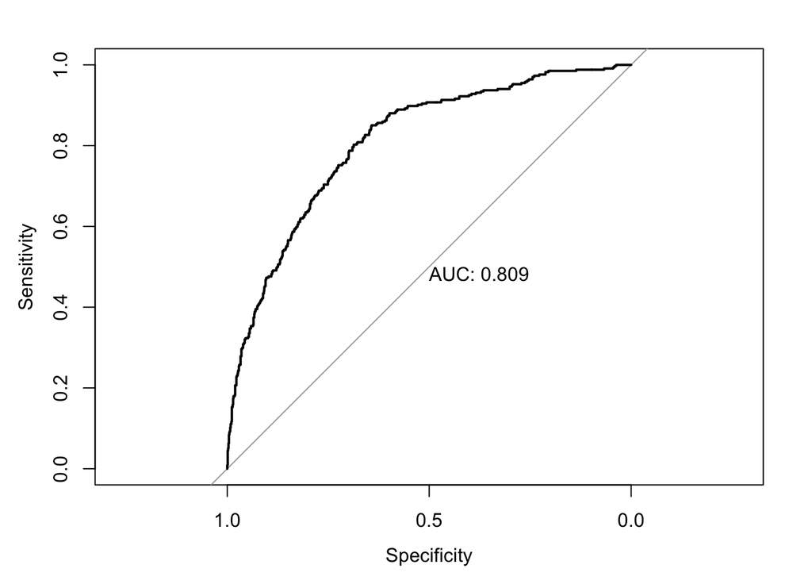

```
## call :
## glm.mids(formula = TARGET_FLAG ~ . - TARGET_AMT, family = "binomial",
##     data = insurance_binned_impute)
##
## call1 :
## mice(data = insurance_bins, m = 1, method = "cart")
##
## nmis :
##   TARGET_FLAG    TARGET_AMT           AGE        INCOME       PARENT1
##             0             0             6           445             0
##       MSTATUS           SEX     EDUCATION           JOB      TRAVTIME
##             0             0             0             0             0
##       CAR_USE      BLUEBOOK      CAR_TYPE       RED_CAR      CLM_FREQ
##             0             0             0             0             0
##       REVOKED       MVR_PTS    URBANICITY   CAR_AGE_BIN  HOME_VAL_BIN
##             0             0             0           510           464
## HAS_HOME_KIDS  HAS_KIDSDRIV  OLDCLAIM_BIN       TIF_BIN       YOJ_BIN
##             0             0             0             0           454
##
## analyses :
## [[1]]
##
## Call:  glm(formula = formula, family = family, data = complete(data,
##     i))
##
## Coefficients:
##                    (Intercept)                             AGE
##                     -1.732e+00                      -8.312e-04
##                         INCOME                      PARENT1Yes
##                     -2.701e-06                       2.550e-01
##                     MSTATUSYes                            SEXM
##                     -5.112e-01                       9.471e-02
##           EDUCATIONHigh School  EDUCATIONLess than High School
##                      3.788e-01                       3.733e-01
##               EDUCATIONMasters                    EDUCATIONPhD
##                      9.629e-02                       1.819e-01
##                    JOBClerical                       JOBDoctor
##                      8.569e-02                      -7.505e-01
##                  JOBHome Maker                       JOBLawyer
##                     -2.479e-01                      -2.096e-01
```

[output cut: 25 more lines]

```
##                     -5.688e-01                       4.001e-01
##            OLDCLAIM_BIN$3k-$6k             OLDCLAIM_BIN$6k-$9k
##                      3.631e-01                       5.061e-01
##           OLDCLAIM_BINOver $9k                TIF_BIN1-4 years
##                      2.882e-02                      -1.938e-01
##               TIF_BIN4-7 years             TIF_BINOver 7 years
##                     -4.321e-01                      -5.915e-01
##      YOJ_BINLess than 10 years      YOJ_BINBetween 10-15 years
##                     -5.772e-01                      -6.280e-01
##           YOJ_BINOver 15 years
##                     -3.939e-01
##
## Degrees of Freedom: 8160 Total (i.e. Null);  8112 Residual
## Null Deviance:       9418
## Residual Deviance: 7246  AIC: 7344
```

```
## Confusion Matrix and Statistics
##
##           Reference
## Prediction   0   1
##          0 861 193
##          1  58 159
##
##                Accuracy : 0.8025
##                  95% CI : (0.7795, 0.8241)
##     No Information Rate : 0.7231
##     P-Value [Acc > NIR] : 3.646e-11
##
##                   Kappa : 0.4407
##
##  Mcnemar's Test P-Value : < 2.2e-16
##
##             Sensitivity : 0.9369
##             Specificity : 0.4517
##          Pos Pred Value : 0.8169
##          Neg Pred Value : 0.7327
##              Prevalence : 0.7231
##          Detection Rate : 0.6774
##    Detection Prevalence : 0.8293
##       Balanced Accuracy : 0.6943
##
##        'Positive' Class : 0
##
```

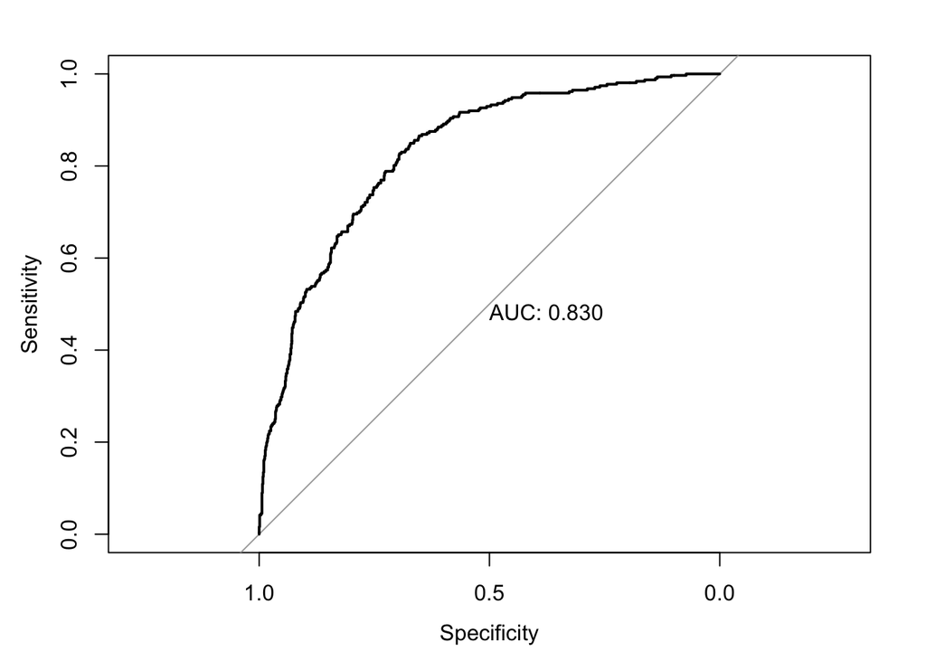

### Multiple Linear Regression

First, let’s look at the multiple linear regression using all variables. The R^2 value is very low, around 4%, and many of the variables are not significant.

```
##
## Call:
## lm(formula = TARGET_AMT ~ ., data = mlr_crash)
##
## Residuals:
##    Min     1Q Median     3Q    Max
##  -9657  -3165  -1474    574  76279
##
## Coefficients:
##                                  Estimate Std. Error t value Pr(>|t|)
## (Intercept)                     4.075e+03  1.809e+03   2.253   0.0244 *
## KIDSDRIV                       -1.771e+02  3.556e+02  -0.498   0.6185
## AGE                             5.833e-01  2.351e+01   0.025   0.9802
## HOMEKIDS                        2.752e+02  2.295e+02   1.199   0.2306
## YOJ                             1.917e+01  5.463e+01   0.351   0.7256
## INCOME                         -1.510e-02  7.821e-03  -1.930   0.0537 .
## PARENT1Yes                     -9.951e+01  6.469e+02  -0.154   0.8778
## HOME_VAL                        2.230e-03  2.268e-03   0.984   0.3255
## MSTATUSYes                     -1.387e+03  5.662e+02  -2.450   0.0144 *
## SEXM                            1.816e+03  7.167e+02   2.534   0.0114 *
## EDUCATIONHigh School           -8.578e+02  5.772e+02  -1.486   0.1374
## EDUCATIONLess than High School -1.712e+02  7.149e+02  -0.239   0.8108
## EDUCATIONMasters                6.457e+02  1.048e+03   0.616   0.5380
## EDUCATIONPhD                    2.938e+03  1.282e+03   2.293   0.0220 *
## JOBClerical                    -1.143e+03  6.452e+02  -1.772   0.0766 .
## JOBDoctor                      -3.784e+03  1.998e+03  -1.894   0.0584 .
## JOBHome Maker                  -1.046e+03  9.995e+02  -1.047   0.2954
## JOBLawyer                      -6.243e+02  1.323e+03  -0.472   0.6370
## JOBManager                     -1.788e+03  1.042e+03  -1.716   0.0864 .
## JOBOther Job                   -4.589e+02  1.304e+03  -0.352   0.7250
## JOBProfessional                 7.702e+02  7.712e+02   0.999   0.3181
## JOBStudent                     -1.059e+03  8.089e+02  -1.309   0.1905
## TRAVTIME                        4.108e+00  1.234e+01   0.333   0.7393
## CAR_USEPrivate                 -2.737e+02  5.849e+02  -0.468   0.6399
## BLUEBOOK                        1.486e-01  3.376e-02   4.402 1.14e-05 ***
## TIF                            -5.847e+00  4.695e+01  -0.125   0.9009
## CAR_TYPEPanel Truck            -2.619e+02  1.053e+03  -0.249   0.8036
## CAR_TYPEPickup                  3.003e+02  6.627e+02   0.453   0.6505
## CAR_TYPESports Car              1.951e+03  8.262e+02   2.361   0.0183 *
## CAR_TYPESUV                     1.657e+03  7.363e+02   2.251   0.0245 *
## CAR_TYPEVan                    -2.228e+02  8.588e+02  -0.259   0.7953
## RED_CARyes                     -3.138e+02  5.511e+02  -0.569   0.5692
## OLDCLAIM                        5.024e-02  2.528e-02   1.987   0.0471 *
## CLM_FREQ                       -2.048e+02  1.749e+02  -1.171   0.2416
## REVOKEDYes                     -1.259e+03  5.850e+02  -2.152   0.0315 *
## MVR_PTS                         8.937e+01  7.564e+01   1.182   0.2375
## CAR_AGE                        -9.797e+01  4.878e+01  -2.009   0.0447 *
## URBANICITYHighly Urban/ Urban   5.991e+01  8.182e+02   0.073   0.9416
## ---
## Signif. codes:  0 '***' 0.001 '**' 0.01 '*' 0.05 '.' 0.1 ' ' 1
##
## Residual standard error: 7586 on 1665 degrees of freedom
##   (450 observations deleted due to missingness)
## Multiple R-squared:  0.04273,    Adjusted R-squared:  0.02145
## F-statistic: 2.009 on 37 and 1665 DF,  p-value: 0.000334
```

Using our log transformation on certain variables, the results are slightly worse.

```
##
## Call:
## lm(formula = TARGET_AMT ~ ., data = mlr_crash_transf)
##
## Residuals:
##    Min     1Q Median     3Q    Max
##  -8045  -3199  -1526    438  99546
##
## Coefficients:
##                                 Estimate Std. Error t value Pr(>|t|)
## (Intercept)                    -9715.099   4630.184  -2.098   0.0360 *
## KIDSDRIV                        -186.329    320.282  -0.582   0.5608
## AGE                              544.526    882.174   0.617   0.5371
## HOMEKIDS                         187.340    209.948   0.892   0.3723
## YOJ                                8.150     61.050   0.133   0.8938
## INCOME                            22.840     96.307   0.237   0.8126
## PARENT1Yes                       331.308    588.943   0.563   0.5738
## HOME_VAL                          58.650     38.287   1.532   0.1257
## MSTATUSYes                      -868.702    509.343  -1.706   0.0882 .
## SEXM                            1212.639    630.947   1.922   0.0547 .
## EDUCATIONHigh School            -457.376    505.973  -0.904   0.3661
## EDUCATIONLess than High School    51.500    635.038   0.081   0.9354
## EDUCATIONMasters                 548.316    883.446   0.621   0.5349
## EDUCATIONPhD                    1658.219   1088.609   1.523   0.1278
## JOBClerical                      -85.075    581.159  -0.146   0.8836
## JOBDoctor                      -2759.504   1870.439  -1.475   0.1403
## JOBHome Maker                    -73.493    941.671  -0.078   0.9378
## JOBLawyer                       -249.977   1173.707  -0.213   0.8314
## JOBManager                     -1310.356    904.347  -1.449   0.1475
## JOBOther Job                    -529.041   1140.250  -0.464   0.6427
## JOBProfessional                  509.067    684.161   0.744   0.4569
## JOBStudent                       317.311    799.632   0.397   0.6915
## TRAVTIME                         -51.921    299.067  -0.174   0.8622
## CAR_USEPrivate                  -345.492    522.462  -0.661   0.5085
## BLUEBOOK                        1398.356    328.055   4.263 2.11e-05 ***
## TIF                              -14.903     42.536  -0.350   0.7261
## CAR_TYPEPanel Truck              -29.775    881.064  -0.034   0.9730
## CAR_TYPEPickup                  -136.236    596.552  -0.228   0.8194
## CAR_TYPESports Car              1011.268    735.029   1.376   0.1690
## CAR_TYPESUV                      677.040    643.223   1.053   0.2927
## CAR_TYPEVan                      135.500    762.155   0.178   0.8589
## RED_CARyes                      -192.707    497.240  -0.388   0.6984
## OLDCLAIM                           7.773     67.902   0.114   0.9089
## CLM_FREQ                         -67.375    232.751  -0.289   0.7722
## REVOKEDYes                      -765.210    422.770  -1.810   0.0704 .
## MVR_PTS                          126.448     70.048   1.805   0.0712 .
## CAR_AGE                         -380.023    263.152  -1.444   0.1489
## URBANICITYHighly Urban/ Urban     31.111    755.064   0.041   0.9671
## ---
## Signif. codes:  0 '***' 0.001 '**' 0.01 '*' 0.05 '.' 0.1 ' ' 1
##
## Residual standard error: 7695 on 2115 degrees of freedom
## Multiple R-squared:  0.02941,    Adjusted R-squared:  0.01244
## F-statistic: 1.732 on 37 and 2115 DF,  p-value: 0.004147
```

Now let’s use backwards elimination to remove some of variables that are not significant.

```
##
## Call:
## lm(formula = TARGET_AMT ~ BLUEBOOK + MVR_PTS, data = mlr_crash_transf)
##
## Residuals:
##    Min     1Q Median     3Q    Max
##  -7511  -3151  -1545    328 100673
##
## Coefficients:
##             Estimate Std. Error t value Pr(>|t|)
## (Intercept) -8251.14    2363.18  -3.492  0.00049 ***
## BLUEBOOK     1453.68     250.36   5.806 7.33e-09 ***
## MVR_PTS       130.32      64.22   2.029  0.04256 *
## ---
## Signif. codes:  0 '***' 0.001 '**' 0.01 '*' 0.05 '.' 0.1 ' ' 1
##
## Residual standard error: 7681 on 2150 degrees of freedom
## Multiple R-squared:  0.017,  Adjusted R-squared:  0.01609
## F-statistic: 18.59 on 2 and 2150 DF,  p-value: 9.889e-09
```

Now let’s use forward addition to add of variables one at a time.

```
##
## Call:
## lm(formula = TARGET_AMT ~ BLUEBOOK + MVR_PTS + SEX + MSTATUS +
##     HOME_VAL + REVOKED + CAR_AGE, data = mlr_crash_transf)
##
## Residuals:
##    Min     1Q Median     3Q    Max
##  -7364  -3150  -1572    412 100285
##
## Coefficients:
##             Estimate Std. Error t value Pr(>|t|)
## (Intercept) -7400.44    2375.76  -3.115  0.00186 **
## BLUEBOOK     1395.31     254.57   5.481 4.73e-08 ***
## MVR_PTS       130.71      64.27   2.034  0.04209 *
## SEXM          637.15     333.97   1.908  0.05655 .
## MSTATUSYes   -914.64     405.32  -2.257  0.02413 *
## HOME_VAL       57.02      34.32   1.661  0.09682 .
## REVOKEDYes   -677.87     409.37  -1.656  0.09790 .
## CAR_AGE      -227.51     208.34  -1.092  0.27495
## ---
## Signif. codes:  0 '***' 0.001 '**' 0.01 '*' 0.05 '.' 0.1 ' ' 1
##
## Residual standard error: 7667 on 2145 degrees of freedom
## Multiple R-squared:  0.02284,    Adjusted R-squared:  0.01966
## F-statistic: 7.164 on 7 and 2145 DF,  p-value: 1.71e-08
```

The function, *regsubsets()*, will go through iterations to find the best model using parameters = 1,2,3,4,… n. Here we see the model with 13 variables (represented by the red dot) had the lowest cp, which indicates the best model. The R^2 remains to be around 3.5% from about 13 variables and higher, which is extremely low.

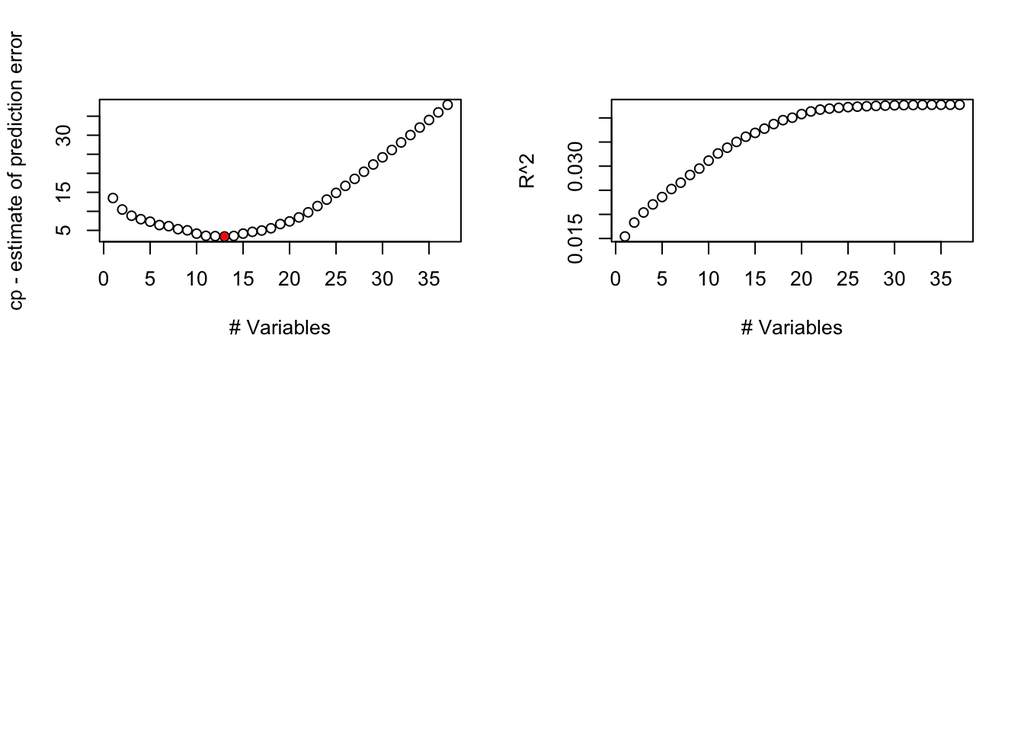

Here we will assume our model has 13 parameters and this gives us the following equation:

```
##          (Intercept)           MSTATUSYes                 SEXM
##         4035.8128827         -953.3672262         1514.2663308
## EDUCATIONHigh School         EDUCATIONPhD          JOBClerical
##         -736.9246986         1787.9808045         -810.1998609
##            JOBDoctor           JOBManager             BLUEBOOK
##        -3707.6686827        -1762.8565981            0.1343502
##   CAR_TYPESports Car          CAR_TYPESUV             OLDCLAIM
##         1648.7049452         1388.8508542            0.0380462
##           REVOKEDYes              CAR_AGE
##        -1052.5481028          -98.6482404
```

Using the regsubsets function and our data that includes log transformations, we see it suggests a model with 7 variables is best look at the cp value.

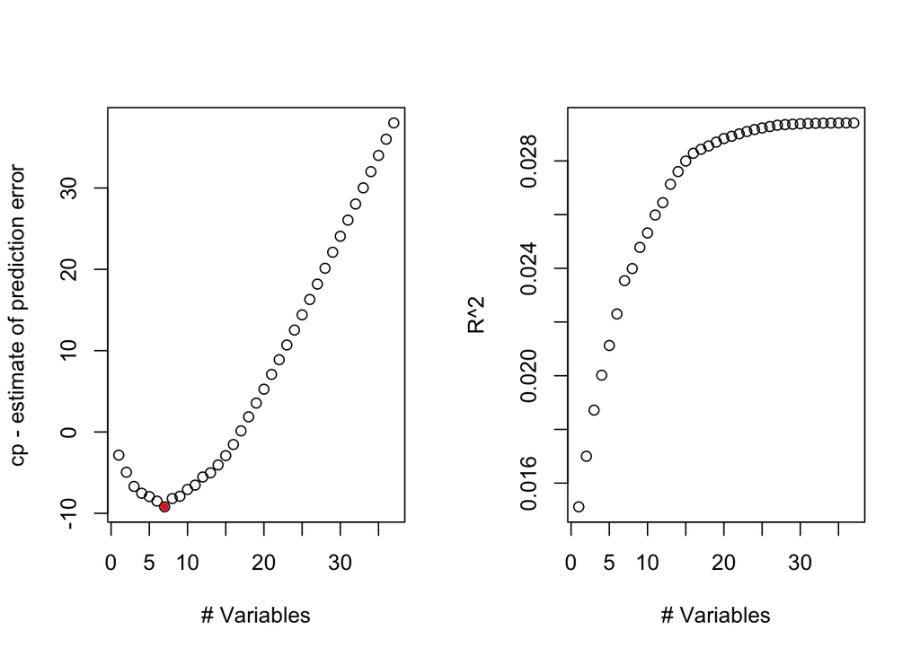

Using the transformed variables, we will choose the model that has 7 parameters since the R^2 value doesn’t change by much as the number of parameters increases. This gives us the following equation:

```
##     (Intercept)      MSTATUSYes    EDUCATIONPhD       JOBDoctor      JOBManager
##    4857.7855103    -866.2249453    2008.6181953   -3283.3214513   -1358.0216839
## JOBProfessional        BLUEBOOK         CAR_AGE
##    1083.6185705       0.1127877     -67.5694404
```

### Multiple Regression Using Leaps

For this model, we will use the log transformation of the response variable. We will also use the predictors that seems to have the most significant relationship for the model.

```
##
## Call:
## lm(formula = log(TARGET_AMT) ~ MSTATUS + SEX + BLUEBOOK + CLM_FREQ +
##     MVR_PTS + EDUCATION, data = mlr_crash_transf)
##
## Residuals:
##     Min      1Q  Median      3Q     Max
## -4.7062 -0.4084  0.0422  0.4048  3.2688
##
## Coefficients:
##                                Estimate Std. Error t value Pr(>|t|)
## (Intercept)                     6.78059    0.25943  26.136  < 2e-16 ***
## MSTATUSYes                     -0.07614    0.03488  -2.183   0.0292 *
## SEXM                            0.05556    0.03503   1.586   0.1128
## BLUEBOOK                        0.15326    0.02712   5.652  1.8e-08 ***
## CLM_FREQ                       -0.02297    0.01457  -1.577   0.1150
## MVR_PTS                         0.01766    0.00705   2.505   0.0123 *
## EDUCATIONHigh School            0.06214    0.04575   1.358   0.1745
## EDUCATIONLess than High School  0.06322    0.05455   1.159   0.2466
## EDUCATIONMasters                0.08379    0.05693   1.472   0.1412
## EDUCATIONPhD                    0.13885    0.08042   1.726   0.0844 .
## ---
## Signif. codes:  0 '***' 0.001 '**' 0.01 '*' 0.05 '.' 0.1 ' ' 1
##
## Residual standard error: 0.804 on 2143 degrees of freedom
## Multiple R-squared:  0.0251, Adjusted R-squared:  0.02101
## F-statistic: 6.131 on 9 and 2143 DF,  p-value: 1.473e-08
```

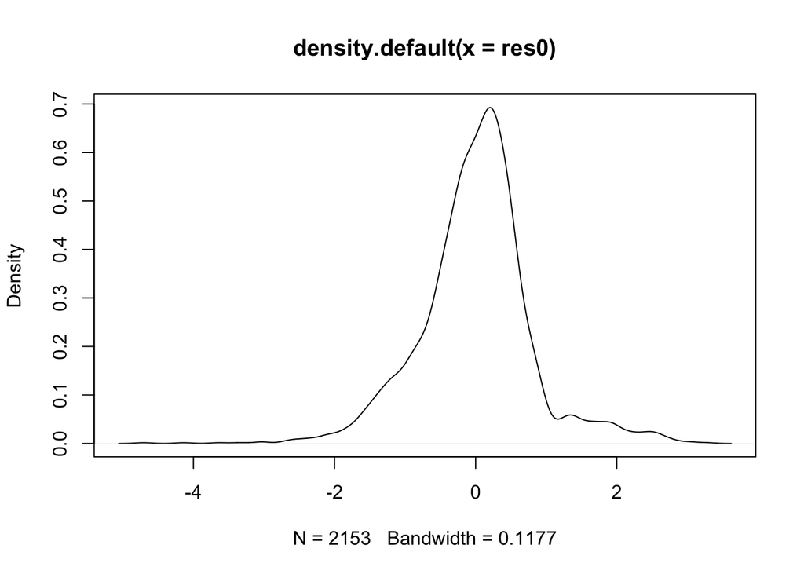

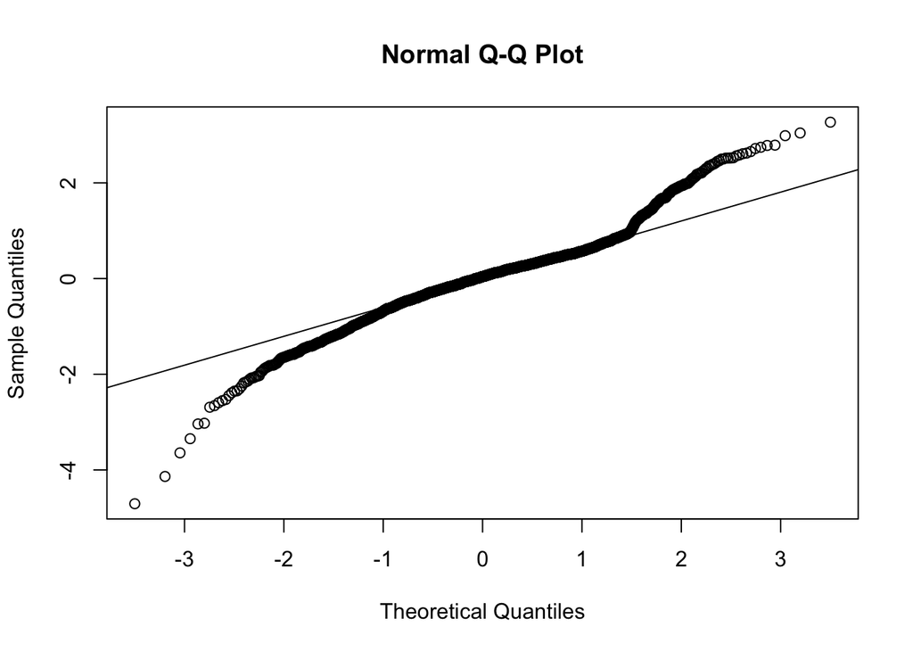

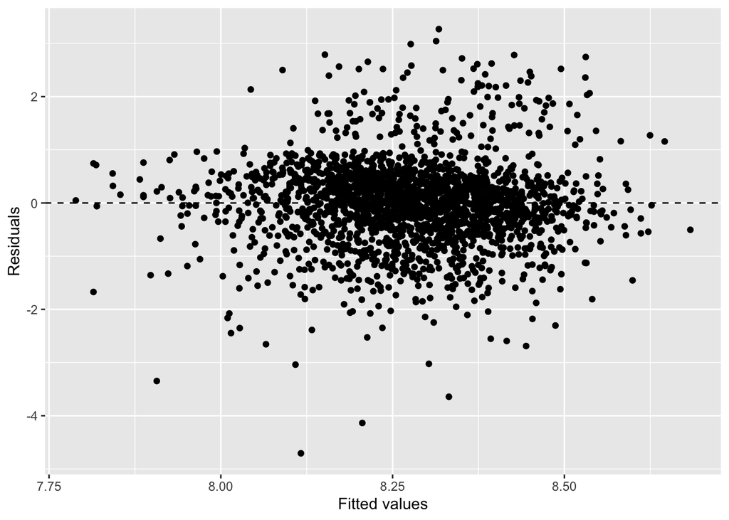